# Histograms and scatterplots

Heath Blackmon

3/8/2019

## Histograms

Histograms are one of the most basic functions that we should be using to look at our data prior to doing any analyses. These plots are essential to detrmine the distribution of our data a key component of deciding what statistical test to do. Fortunately they are super easy to do in R. Then function that we will use is `hist`. Here is an example of simple one:

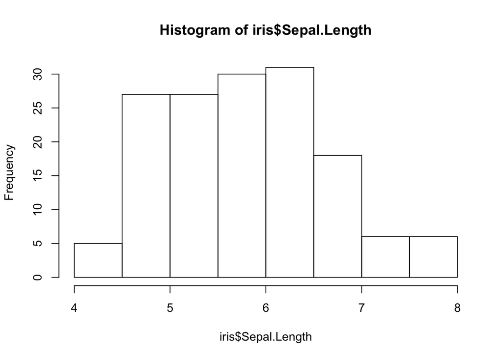

```r
data(iris)
hist(iris$Sepal.Length)
```

We can pretty this up quite a bit using a few extra arguments:

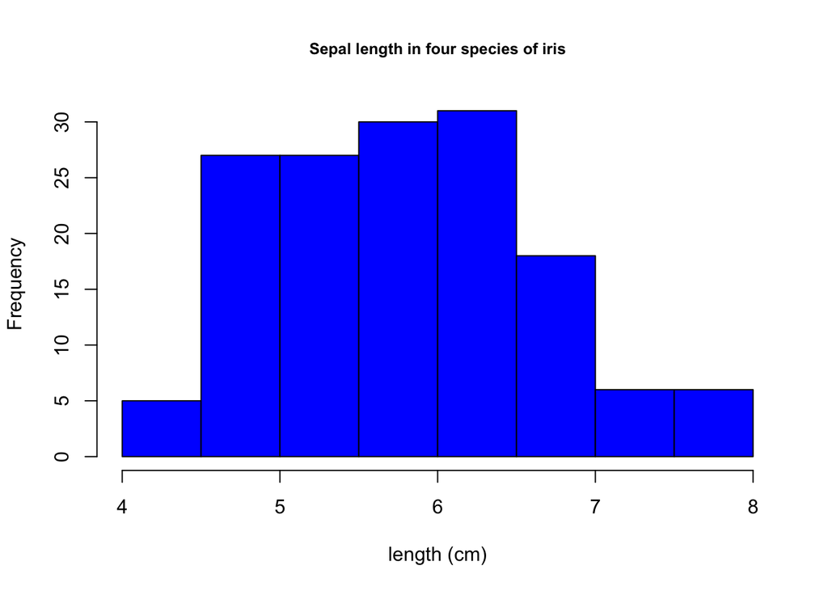

```r
data(iris)
hist(iris$Sepal.Length, xlab="length (cm)",
     main="Sepal length in four species of iris",
     col="blue",
     cex.main=.8)
```

If we have a lot of data and perhaps even measures for multiple varaibles we might want a density plot instead of a simple histogram we can do that too.

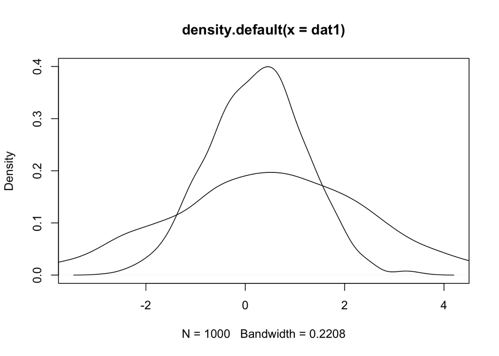

```r
dat1 <- rnorm(1000, mean=.25)
dat2 <- rnorm(3000, mean=.5, sd=2)
plot(density(dat1))
lines(density(dat2))
```

Ok lets fix this in a couple of ways lets expand the X axis and color in these distributions using the `polygon` function and labeling our distributions

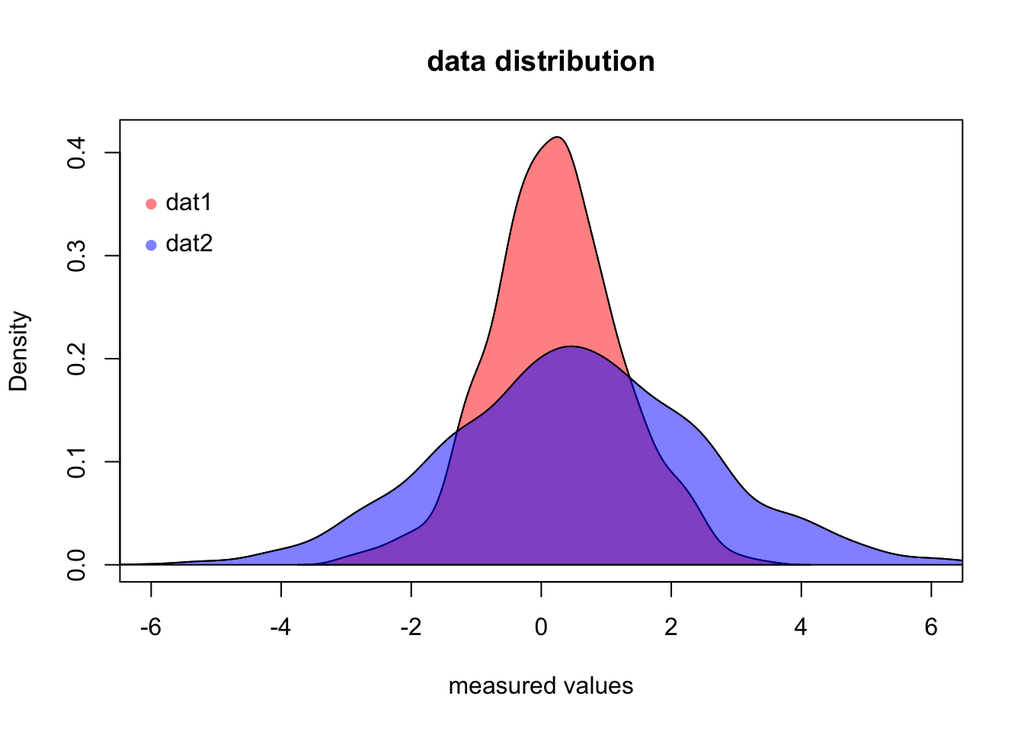

```r
dat1 <- rnorm(1000, mean=.25)
dat2 <- rnorm(3000, mean=.5, sd=2)
plot(density(dat1), xlim=c(-6,6),
     xlab="measured values",
     main="data distribution")
lines(density(dat2))
polygon(density(dat1), col=rgb(1,0,0,.5))
polygon(density(dat2), col=rgb(0,0,1,.5))
points(x=c(-6,-6),y=c(.35,.31), pch=16,
       col=c(rgb(1,0,0,.5), rgb(0,0,1,.5)))
text(x=c(-6,-6),y=c(.35,.31),
     labels=c("dat1", "dat2"), pos=4)
```

Your turn: try making a histogram of 1000 values sampled from a Poisson distribution. Once you’ve done that try the density plot as well.

## Scatter Plots

Scatter plots are key way to quickly see if you have relationships between your data variables. These are easy to make in R using the simple plot function.

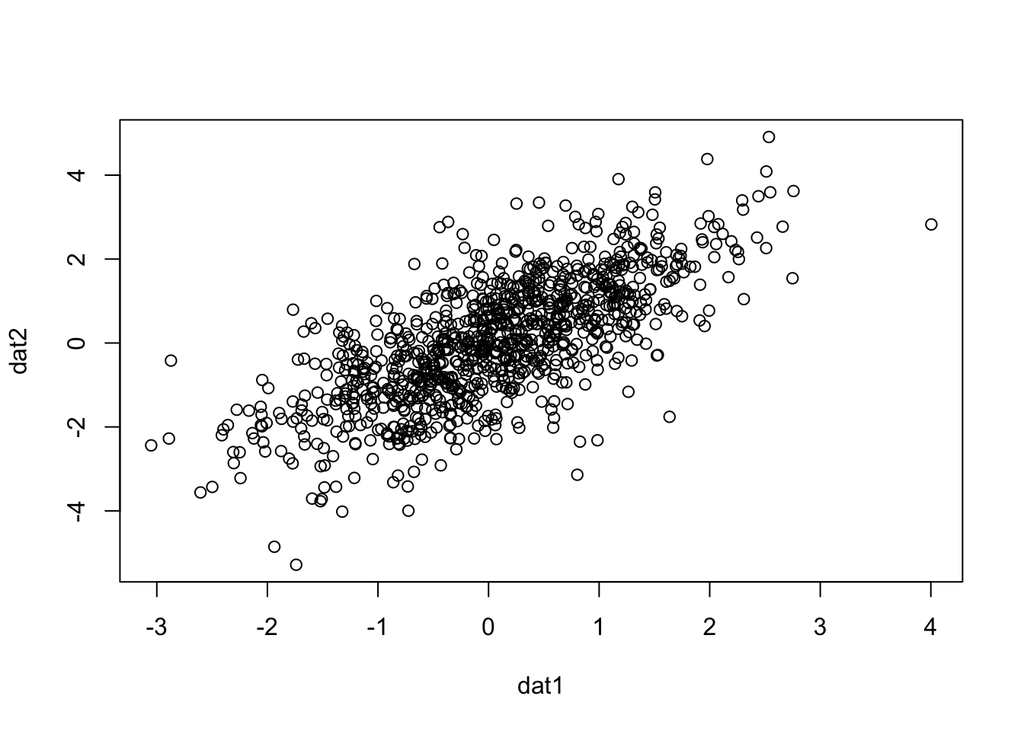

```r
dat1 <- rnorm(1000)
dat2 <- rnorm(mean=dat1, 1000)
plot(x=dat1, y=dat2)
```

Use what you’ve learned above to make this plot beautiful. Try using arguments like `cex`, `pch`, `col`, `xlab`, `ylab`, `main` and more to really get your plot nice enough that you could submit it to a journal or at least to your advisor.